# Business essentials

August 17, 2018

## Overview

In this presentation, you will learn to

- Understand the pros and cons of consulting.
- Define the various business entities that you can use for your consulting business.
- Set up a simple process for billing and accounting.
- Discuss common elements in a consulting contract.
- How to find new customers

I owe a great debt gratitude for the many interesting questions and comments posted on the Statistical Consulting Section discussion forum.

## A bit about myself

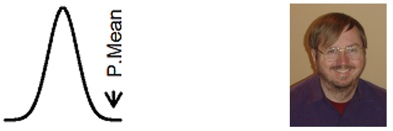

Alt text: My logo, plus a mug shot

## What color is your consulting parachute?

Take 30 seconds and dream about what your life will be like in five years. If you don't mind sharing your dream with the rest of us, that would be appreciated.

Thinking about your goals five years from now will help you understand the type of consulting business that you want to start and will help you take the first steps in that direction.

## Two types of consultants.

You are an internal consultant if

- you are part of a larger organization
- you have a "boss".

You are an independent consulant if

- you work alone (or in a small group)
- you are your own boss.

## How independent consulting is different

Cons

- No support network
- No subsidization for professional development
- Highly variable workload

Pros

- You are your own boss.

## How independent consulting is different

Cons

- No support network
- No subsidization for professional development
- Highly variable workload

Pros

- You are your own boss.

## How independent consulting is different

Cons

- No support network
- No subsidization for professional development
- Highly variable workload

Pros

- You are your own boss.

## How independent consulting is different

Cons

- No support network
- No subsidization for professional development
- Highly variable workload

Pros

- You are your own boss.

## How independent consulting is different

Cons

- No support network
- No subsidization for professional development
- Highly variable workload

Pros

- You are your own boss.

## Various business entities.

- Sole proprietorship
- Business partnership
- Limited Liability Corporation (LLC)
- S chapter/C chapter corporation

Caution: I am not a lawyer. Also laws about business entities vary greatly from state to state.

## Various business entities.

- Sole proprietorship
- Business partnership
- Limited Liability Corporation (LLC)
- S chapter/C chapter corporation

## Various business entities.

- Sole proprietorship
- Business partnership
- Limited Liability Corporation (LLC)
- S chapter/C chapter corporation

## Various business entities.

- Sole proprietorship
- Business partnership
- Limited Liability Corporation (LLC)
- S chapter/C chapter corporation

Caution: I am not a lawyer. Also laws about business entities vary greatly from state to state.

## Various business entities.

- Sole proprietorship
- Business partnership
- Limited Liability Corporation (LLC)
- S chapter/C chapter corporation

## Questions to ask about business entities

- Are you taking out a loan to start your independent consulting business?
- How likely are you to be sued by your customers? High litigation risk may make you seek out the protections of an LLC or S/C corporation.
- How sensitive are you to tax issues?
- How complicated do you want your legal/accounting life to be?

## Questions to ask about business entities

- Are you taking out a loan to start your independent consulting business?
- How likely are you to be sued by your customers? High litigation risk may make you seek out the protections of an LLC or S/C corporation.
- How sensitive are you to tax issues?
- How complicated do you want your legal/accounting life to be?

## Questions to ask about business entities

- Are you taking out a loan to start your independent consulting business?
- How likely are you to be sued by your customers? High litigation risk may make you seek out the protections of an LLC or S/C corporation.
- How sensitive are you to tax issues?
- How complicated do you want your legal/accounting life to be?

## Questions to ask about business entities

- Are you taking out a loan to start your independent consulting business?
- How likely are you to be sued by your customers? High litigation risk may make you seek out the protections of an LLC or S/C corporation.
- How sensitive are you to tax issues?
- How complicated do you want your legal/accounting life to be?

## Accounting – How to bill

You have two choices

- Bill by the project
- Bill by the hour

The average rate is $130 per hour. See the 2006 issue of the Statistical Consulting Section newsletter (v23.1).

## Accounting – Invoicing

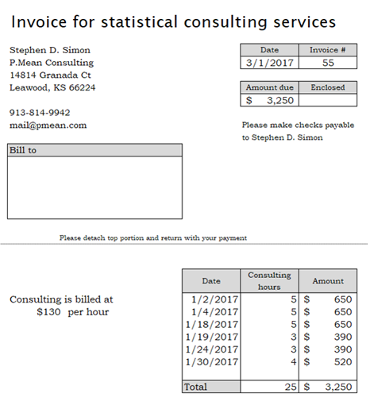

Alt text: Image of a sample invoice

## Accounting – Invoicing

The invoice should include

- your name and address,
- the name and address of your client,
- the date the invoice was printed,
- a unique invoice number,
- who the check should be made out to (your name or your company’s name).
- your price with itemization details, and
- a due date on the invoice or a rate that would apply if the invoice is paid late.

## Accounting - separate checking account.

Set up a business checking account.

- Deposit business income here
- Pay business expenses here
- Transfer money as needed to your personal account.

## Contracts

“A verbal contract isn’t worth the paper it is written on.” Samuel Goldwyn, found at www.brainyquote.com/quotes/quotes/s/samuelgold122394.html

You can dispense with a contract if you trust the other party to treat you fairly or if you are willing to handle an unresolvable dispute by forgoing your consulting fee.

## Contracts

Some elements that this contract could cover include:

- How much and how often you will be paid.
- The scope of work of the project.
- How to handle disputes.
- Issues involving liability (protection against lawsuits involving third parties).
- Assurances about maintaining appropriate confidentiality for any data you receive.

## Contracts

Look out for provisions that

- place all the responsibility in your lap should a third party decide to sue your client.
- limit your ability to seek redress if there is a dispute between you and the client
- place unreasonable demands on you (e.g., carrying an excessive amount of insurance).
- that limit your ability to re-use your own code for other clients.
- that restrict your consulting fee to the lowest amount that you charge anyone else.
- that make your fee contingent on a certain statistical outcome.

## Some good advice on contracts

“I long ago learned the power of "just saying no" in contract negotiations. The vast majority of stuff I cross out, with only a cursory explanation of why (no need to write paragraphs) is accepted with no objection whatsoever. I'm not shy about crossing out lots of things, either. It's often standard boilerplate whose purpose was long forgotten, or stuff some lazy lawyer put in either so they could use the same contract for everything or to avoid having to question the client as to what protections they really needed. If there's an actual reason for it that applies to your situation, you'll hear about it once you say "no," and can go from there.” David Lyon, Email to the Statistics Consulting Section of the ASA, August 30, 2014.

## Insurance – personal insurance

Personal insurance

- Life insurance
- Health insurance
- Disability insurance
- etc.

## Insurance – business insurance

Business insurance

- Liability insurance
- Errors and Omissions insurance

## Insurance – business insurance

Business insurance

- Liability insurance
- Errors and Omissions (E&O) insurance

## Summary

In this talk, we reviewed the

- business entities,
- billing options,
- contacts, and
- insurance options.

The slides for this talk are available at

- https://github.com/pmean/business-essentials